# Real Estate Regression

Piotr Wieczorek

2023-05-14

## **Goal of this project**

#### The goal of this project is to create possibly best-fitted linear model to predict Y_house_price_of_unit_area

## **Importing libraries**

```r
library("ggplot2")
library("MLmetrics")
library("ggthemes")
library("hrbrthemes")
library("glue")
library("moments")
library("caret")
library("dplyr")
library("tidyverse")
library("corrplot")
library("stringr")
library("markdown")
library("knitr")
library("gridExtra")
library("car")
library("lmtest")
library("whitestrap")
library("kableExtra")
library("DT")
library("vtable")
library("fastDummies")
library("janitor")
```

## **Reading and cleaning the data**

```r
df <- read_csv("C:/Users/piotr/Desktop/pythonfiles/Real estate.csv")
```

```r
df <- df %>%
  janitor::clean_names()
```

```r
colnames(df)
```

```
## [1] "no"
## [2] "x1_transaction_date"
## [3] "x2_house_age"
## [4] "x3_distance_to_the_nearest_mrt_station"
## [5] "x4_number_of_convenience_stores"
## [6] "x5_latitude"
## [7] "x6_longitude"
## [8] "y_house_price_of_unit_area"
```

```r
df$x1_transaction_date <- as.integer(df$x1_transaction_date)
df <- df[,-1]
```

```r
df %>%
  head() %>%
  kable(align = "c") %>%
  kable_styling(position="center") %>%
  scroll_box(width = "100%")
```

| x1_transaction_date | x2_house_age | x3_distance_to_the_nearest_mrt_station | x4_number_of_convenience_stores | x5_latitude | x6_longitude | y_house_price_of_unit_area |
| --- | --- | --- | --- | --- | --- | --- |
| 2012 | 32.0 | 84.87882 | 10 | 24.98298 | 121.5402 | 37.9 |
| 2012 | 19.5 | 306.59470 | 9 | 24.98034 | 121.5395 | 42.2 |
| 2013 | 13.3 | 561.98450 | 5 | 24.98746 | 121.5439 | 47.3 |
| 2013 | 13.3 | 561.98450 | 5 | 24.98746 | 121.5439 | 54.8 |
| 2012 | 5.0 | 390.56840 | 5 | 24.97937 | 121.5425 | 43.1 |
| 2012 | 7.1 | 2175.03000 | 3 | 24.96305 | 121.5125 | 32.1 |

```r
df %>%
  head() %>%
  kable(align = "c") %>%
  kable_styling(position="center") %>%
  scroll_box(width = "100%")
```

| x1_transaction_date | x2_house_age | x3_distance_to_the_nearest_mrt_station | x4_number_of_convenience_stores | x5_latitude | x6_longitude | y_house_price_of_unit_area |
| --- | --- | --- | --- | --- | --- | --- |
| 2012 | 32.0 | 84.87882 | 10 | 24.98298 | 121.5402 | 37.9 |
| 2012 | 19.5 | 306.59470 | 9 | 24.98034 | 121.5395 | 42.2 |
| 2013 | 13.3 | 561.98450 | 5 | 24.98746 | 121.5439 | 47.3 |
| 2013 | 13.3 | 561.98450 | 5 | 24.98746 | 121.5439 | 54.8 |
| 2012 | 5.0 | 390.56840 | 5 | 24.97937 | 121.5425 | 43.1 |
| 2012 | 7.1 | 2175.03000 | 3 | 24.96305 | 121.5125 | 32.1 |

## **Exploring the data**

```r
df[,-1] %>%
  st(add.median=TRUE)
```

Summary Statistics

| Variable | N | Mean | Std. Dev. | Min | Pctl. 25 | Pctl. 50 | Pctl. 75 | Max |
| --- | --- | --- | --- | --- | --- | --- | --- | --- |
| x2_house_age | 414 | 18 | 11 | 0 | 9 | 16 | 28 | 44 |
| x3_distance_to_the_nearest_mrt_station | 414 | 1084 | 1262 | 23 | 289 | 492 | 1454 | 6488 |
| x4_number_of_convenience_stores | 414 | 4.1 | 2.9 | 0 | 1 | 4 | 6 | 10 |
| x5_latitude | 414 | 25 | 0.012 | 25 | 25 | 25 | 25 | 25 |
| x6_longitude | 414 | 122 | 0.015 | 121 | 122 | 122 | 122 | 122 |
| y_house_price_of_unit_area | 414 | 38 | 14 | 7.6 | 28 | 38 | 47 | 118 |

## **Exploring variable’s distribution - shapiro wilk test, skewness and kurtosis**

```r
df_shapiro = data.frame()
for (i in colnames(df)){
    shapiro = shapiro.test(df[[i]])
    p_val = shapiro$p.value
    w_stat = round(shapiro$statistic,2)
    skew = round(skewness(df[[i]]),2)
    kurt = round(kurtosis(df[[i]]),2)
    output = c(p_val,w_stat,skew,kurt)
    df_shapiro = rbind(df_shapiro,output)
  }
```

```r
colnames(df_shapiro) <- c('p_value','w_stat','skewness','kurtosis')
rownames(df_shapiro) <- colnames(df)
df_shapiro %>%
  kable(align = "c") %>%
  kable_styling(position="center")
```

|  | p_value | w_stat | skewness | kurtosis |
| --- | --- | --- | --- | --- |
| x1_transaction_date | 0e+00 | 0.58 | -0.85 | 1.72 |
| x2_house_age | 0e+00 | 0.95 | 0.38 | 2.12 |
| x3_distance_to_the_nearest_mrt_station | 0e+00 | 0.74 | 1.88 | 6.15 |
| x4_number_of_convenience_stores | 0e+00 | 0.94 | 0.15 | 1.93 |
| x5_latitude | 7e-07 | 0.97 | -0.44 | 3.25 |
| x6_longitude | 0e+00 | 0.87 | -1.22 | 4.17 |
| y_house_price_of_unit_area | 5e-07 | 0.97 | 0.60 | 5.14 |

```r
df
```

```
## # A tibble: 414 × 7
##    x1_transaction_date x2_house_age x3_distanc…¹ x4_nu…² x5_la…³ x6_lo…⁴ y_hou…⁵
##                  <int>        <dbl>        <dbl>   <dbl>   <dbl>   <dbl>   <dbl>
##  1                2012         32           84.9      10    25.0    122.    37.9
##  2                2012         19.5        307.        9    25.0    122.    42.2
##  3                2013         13.3        562.        5    25.0    122.    47.3
##  4                2013         13.3        562.        5    25.0    122.    54.8
##  5                2012          5          391.        5    25.0    122.    43.1
##  6                2012          7.1       2175.        3    25.0    122.    32.1
##  7                2012         34.5        623.        7    25.0    122.    40.3
##  8                2013         20.3        288.        6    25.0    122.    46.7
##  9                2013         31.7       5512.        1    25.0    121.    18.8
## 10                2013         17.9       1783.        3    25.0    122.    22.1
## # … with 404 more rows, and abbreviated variable names
## #   ¹x3_distance_to_the_nearest_mrt_station, ²x4_number_of_convenience_stores,
## #   ³x5_latitude, ⁴x6_longitude, ⁵y_house_price_of_unit_area
```

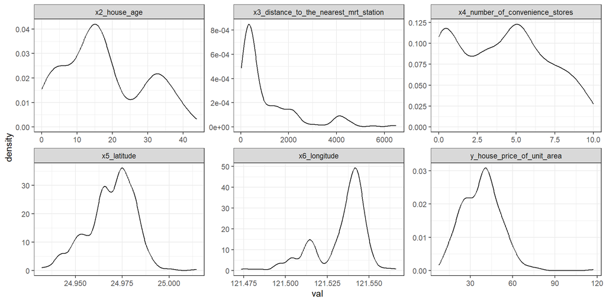

```r
df %>%
  select(2:7) %>%
  gather(c(1:6),key="key",value="val") %>%
  ggplot(aes(x=val))+
  geom_density()+
  facet_wrap(~key,scales="free") +
  theme_bw()
```

## **Taking the log() of the Y variable**

#### Price is a typical variable that usually has extensive outliers, as it is in this example. It will highly influence the residuals in modelling price, therefore it was decided to take log() of it in order to minimize the outliers and push the distribution more toward normality

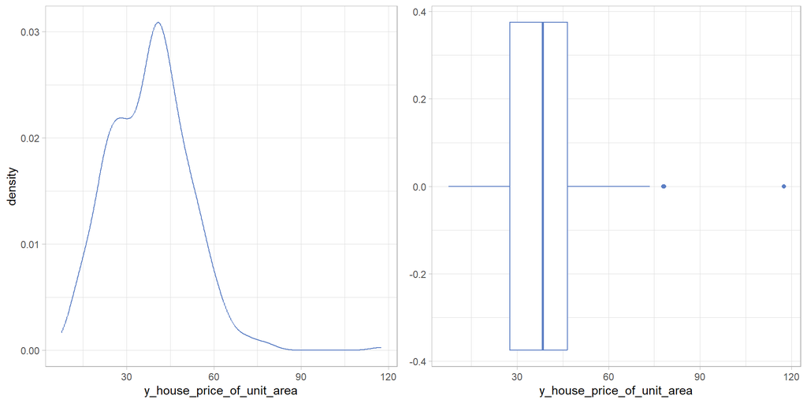

```r
plot1 = df %>%
  ggplot(aes(x=y_house_price_of_unit_area)) +
  geom_boxplot(color="#5B7EC4")+
  theme_light()

plot2 = df %>%
  ggplot(aes(x=y_house_price_of_unit_area)) +
  geom_density(color="#5B7EC4")+
  theme_light()

grid.arrange(plot2,plot1,nrow =1, ncol=2)
```

### **Density after taking the log() of price**

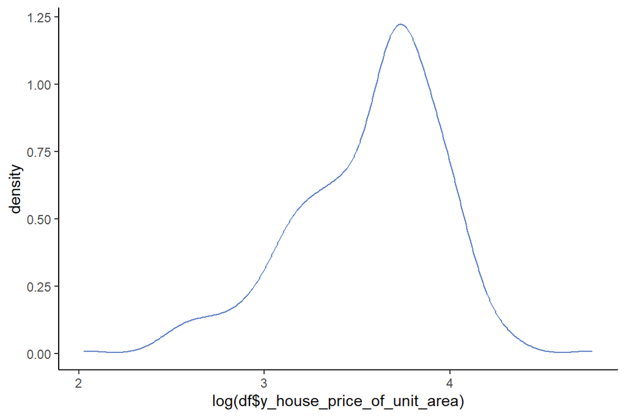

```r
df %>%
  ggplot(aes(x=log(df$y_house_price_of_unit_area)))+
  geom_density(color = "#5B7EC4")+
  theme_classic()
```

### **Exploring correlation**

#### Note that the spearman correlation was used because of the variable’s distribution and there is no linear dependency between house price and some of the variables.

```r
for (i in colnames(df)){
  if (! (i == "y_house_price_of_unit_area")){
    print(glue("corr {i} and log(y_house_price_of_unit_area) = {round(cor(log(df$y_house_price_of_unit_area),df[[i]],method = 'spearman'),2)}"))
  }
}
```

```
## corr x1_transaction_date and log(y_house_price_of_unit_area) = 0.07
## corr x2_house_age and log(y_house_price_of_unit_area) = -0.28
## corr x3_distance_to_the_nearest_mrt_station and log(y_house_price_of_unit_area) = -0.78
## corr x4_number_of_convenience_stores and log(y_house_price_of_unit_area) = 0.62
## corr x5_latitude and log(y_house_price_of_unit_area) = 0.58
## corr x6_longitude and log(y_house_price_of_unit_area) = 0.44
```

#### Scatter plots will be helpful to decide whether or not to transform the independent variables in the modelling part

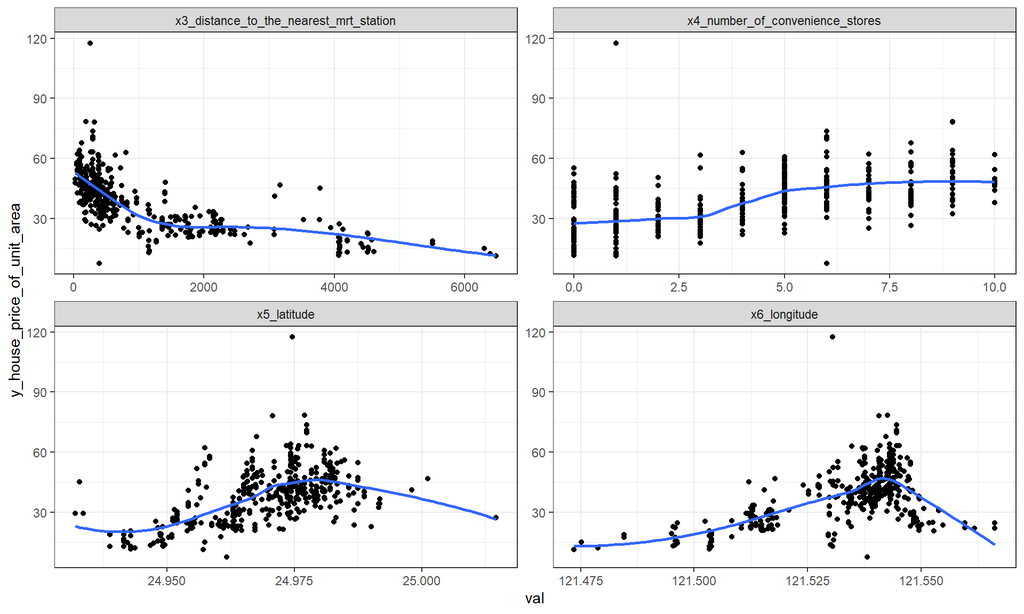

```r
df %>%
  select(3:7) %>%
  gather(c(1:4),key="key",value="val") %>%
  ggplot(aes(x=val,y=y_house_price_of_unit_area))+
  geom_point()+
  geom_smooth(se=F)+
  facet_wrap(~key,scales="free") +
  theme_bw()
```

#### In order to create a corrplot picturing correlation between independent variables, colnames were slightly changed to display the plot in a more readable way

```r
colnames(df)
```

```
## [1] "x1_transaction_date"
## [2] "x2_house_age"
## [3] "x3_distance_to_the_nearest_mrt_station"
## [4] "x4_number_of_convenience_stores"
## [5] "x5_latitude"
## [6] "x6_longitude"
## [7] "y_house_price_of_unit_area"
```

```r
list_col <- c()
for (i in 1:7){
  col_name <- strsplit(colnames(df),"_")[[i]][1]
  list_col <- append(list_col,col_name)
}
list_col
```

```
## [1] "x1" "x2" "x3" "x4" "x5" "x6" "y"
```

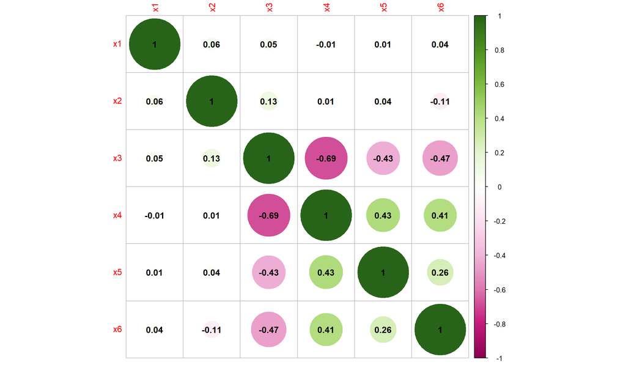

```r
df2 <- df
colnames(df2) <- list_col
corrplot(cor(df2[,1:6],method='spearman'), addCoef.col = 'black',col = COL2('PiYG'))
```

## **Modelling part**:

### **Data partition**

```r
set.seed(1)
train_indices <- createDataPartition(y = df$y_house_price_of_unit_area,times=1,p=.7,list=FALSE)

df_train <- df[train_indices,]
df_test <- df[-train_indices,]

nrow(df_train)
```

```
## [1] 292
```

```r
nrow(df_test)
```

```
## [1] 122
```

```r
nrow(df_train)/(nrow(df_train) + nrow(df_test))
```

```
## [1] 0.705314
```

#### Several models were created and such choice of variables demonstrated the highest R^2 and F-statistic, as well as the lowest Pr(>|t|)

```r
model <- lm(formula = log(y_house_price_of_unit_area) ~ log(x3_distance_to_the_nearest_mrt_station) + x5_latitude,
  data = df_train)
summary(model)
```

```
##
## Call:
## lm(formula = log(y_house_price_of_unit_area) ~ log(x3_distance_to_the_nearest_mrt_station) +
##     x5_latitude, data = df_train)
##
## Residuals:
##     Min      1Q  Median      3Q     Max
## -1.5387 -0.1258  0.0244  0.1153  1.0335
##
## Coefficients:
##                                               Estimate Std. Error t value
## (Intercept)                                 -285.14752   32.98654  -8.644
## log(x3_distance_to_the_nearest_mrt_station)   -0.20194    0.01442 -14.003
## x5_latitude                                   11.61462    1.31922   8.804
##                                             Pr(>|t|)
## (Intercept)                                 3.78e-16 ***
## log(x3_distance_to_the_nearest_mrt_station)  < 2e-16 ***
## x5_latitude                                  < 2e-16 ***
## ---
## Signif. codes:  0 '***' 0.001 '**' 0.01 '*' 0.05 '.' 0.1 ' ' 1
##
## Residual standard error: 0.237 on 289 degrees of freedom
## Multiple R-squared:  0.6507, Adjusted R-squared:  0.6483
## F-statistic: 269.2 on 2 and 289 DF,  p-value: < 2.2e-16
```

### **Residuals diagnostic (train data set)**

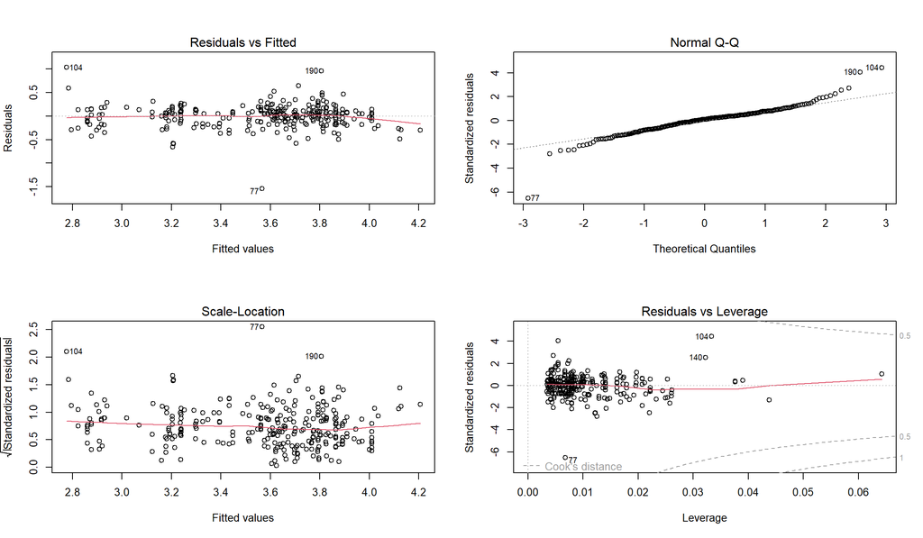

```r
par(mfrow=c(2,2))
plot(model)
```

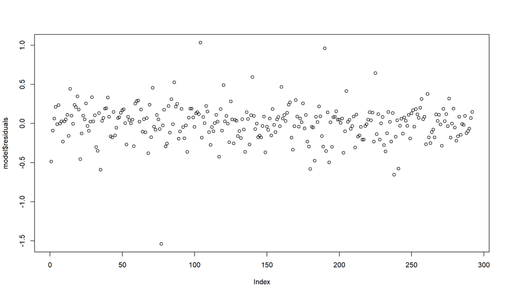

```r
plot(model$residuals)
```

### **Residuals distribution (train data set)**

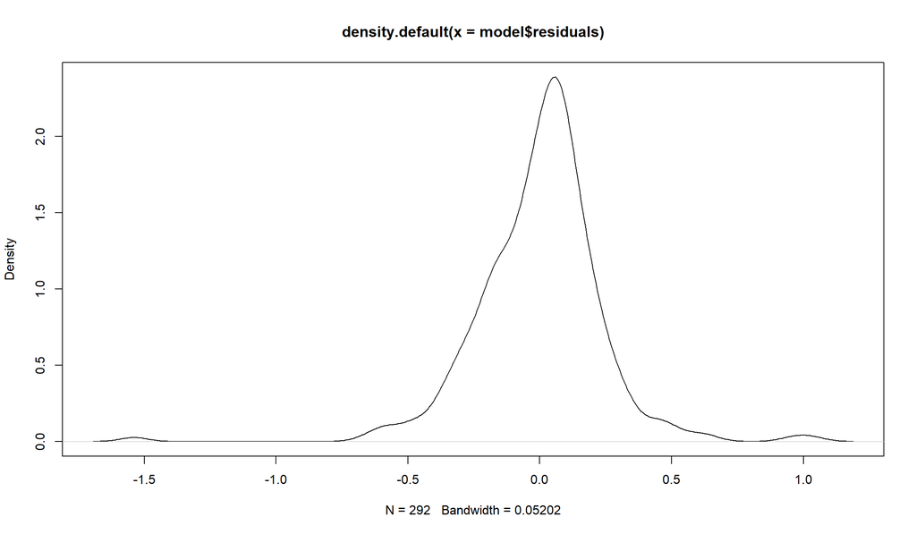

```r
plot(density(model$residuals))
```

#### The Shapiro-Wilk test returned very low p-value, which (apart from the plot above) proves that the residuals’ distribution is not normal

```r
shapiro.test(model$residuals)
```

```
##
##  Shapiro-Wilk normality test
##
## data:  model$residuals
## W = 0.91953, p-value = 1.979e-11
```

## **Using the model to predict data from df_test**

```r
prediction <- predict(model, newdata = df_test)
```

```r
head(prediction)
```

```
##        1        2        3        4        5        6
## 3.678277 3.188332 3.728806 3.749202 4.206469 3.228759
```

### **Adding predicted values and residuals to df_test**

```r
df_test$predicted_price_log <- prediction
df_test$residual <- log(df_test$y_house_price_of_unit_area) - df_test$predicted_price_log
df_test$y_house_price_of_unit_area_log <- log(df_test$y_house_price_of_unit_area)
df_test %>%
  head() %>%
  kable(align = "c") %>%
  kable_styling(position="center") %>%
  scroll_box(width = "100%")
```

| x1_transaction_date | x2_house_age | x3_distance_to_the_nearest_mrt_station | x4_number_of_convenience_stores | x5_latitude | x6_longitude | y_house_price_of_unit_area | predicted_price_log | residual | y_house_price_of_unit_area_log |
| --- | --- | --- | --- | --- | --- | --- | --- | --- | --- |
| 2012 | 34.5 | 623.47310 | 7 | 24.97933 | 121.5364 | 40.3 | 3.678277 | 0.0180741 | 3.696352 |
| 2012 | 20.4 | 2469.64500 | 4 | 24.96108 | 121.5105 | 23.8 | 3.188333 | -0.0186469 | 3.169686 |
| 2013 | 35.7 | 579.20830 | 2 | 24.98240 | 121.5462 | 50.5 | 3.728806 | 0.1931674 | 3.921973 |
| 2012 | 17.7 | 350.85150 | 1 | 24.97544 | 121.5312 | 37.4 | 3.749202 | -0.1275309 | 3.621671 |
| 2012 | 1.5 | 23.38284 | 7 | 24.96772 | 121.5410 | 47.7 | 4.206469 | -0.3415372 | 3.864931 |
| 2013 | 4.5 | 2275.87700 | 3 | 24.96314 | 121.5115 | 29.3 | 3.228759 | 0.1488285 | 3.377588 |

## **Residuals diagnostic**

#### The line is not perfectly aligned with y=0, but it’s likely due to small sample of the test data.

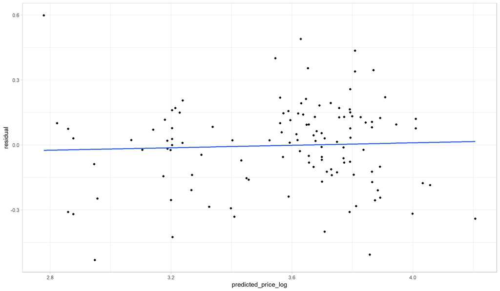

```r
df_test %>%
  ggplot(aes(x = predicted_price_log, y = residual)) +
  geom_point()+
  geom_smooth(method="lm",se=FALSE)+
  theme_light()
```

### **Residuals distribution (test data set)**

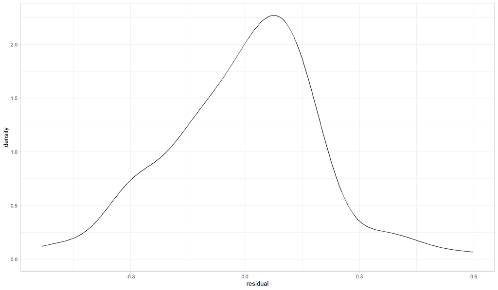

```r
df_test %>%
  ggplot(aes(x=residual)) +
  geom_density()+
  theme_light()
```

### **Q-Q Plot (test data set)**

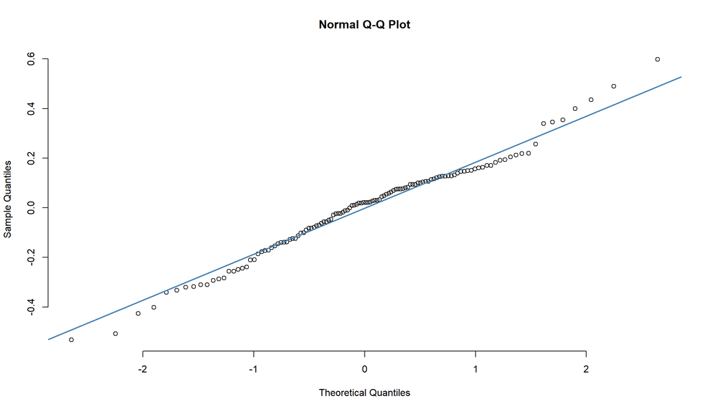

```r
qqnorm(df_test$residual, pch = 1, frame = FALSE)
qqline(df_test$residual, col = "steelblue", lwd = 2)
```

### **Shapiro-Wilk test**

```r
print(shapiro.test(df_test$residual))
```

```
##
##  Shapiro-Wilk normality test
##
## data:  df_test$residual
## W = 0.98359, p-value = 0.1454
```

```r
print(glue("skewness = {round(skewness(df_test$residual),2)}"))
```

```
## skewness = -0.07
```

```r
print(glue("kurtosis = {round(kurtosis(df_test$residual),2)}"))
```

```
## kurtosis = 3.48
```